# Metodos Computacionais: Bootstrap

Gustavo Almeida Silva

# O Bootstrap

Bootstrap é um método que foi introduzido por B. Efron em 1979. Bootstrap usa amostragem com reposição para estimar a distribuição para a variável alvo desejada. O principal objetivo do bootstrap é avaliar a variância do estimador. Outras aplicações podem ser:

- Para estimar intervalos de confiança, erros padrão para o estimador
- Para estimar a precisão de um estimador θ
- Para lidar com dados que não possuem distribuição normal
- Para gerar amostras para experimentos

Bootstrapping tem se mostrado um excelente método para estimar muitas distribuições para estatísticas, às vezes dando melhores resultados do que a aproximação normal tradicional. Também funciona bem com pequenas amostras. Ele não funciona muito bem quando o modelo não é suave, não é uma boa opção para dados dependentes, dados ausentes, censura ou dados com valores discrepantes.

# A utilização da programação funcional

O trabalho desenvolvido nesse relatório tem em seu objetivo desenvolver funções para a simulação amostrais via *Bootstrap* e calculo de estimativas intervalares provenientes das amostras geradas

Assim, existe uma ampla gama de casos onde a abordagem via Bootstrap pode ser bem-vinda, e visando uma possivel disponibilização de um pacote com as funções desenvolvidas aqui, utilizaremos o conceito da **programação funcional** para uma construção que visa encapsular certas funções, facilitar a leitura dos codigos e otimizar a busca por possiveis erros.

Iremos seguir a seguinte metodologia:

- Funções pequenas
  - Prática de separar o algoritmo em funções cada vez mais simples e que naturalmente irá reduzir o tamanho de cada função
- Função e finalidade
  - Funções devem possuir uma única finalidade, ou seja, não basta simplesmente dividir uma função por conta do seu tamanho, ao particionar uma função em outras menores o foco deve ser justamente o unicidade parâmetro de saída.
- Encapsulamento
  - A função disponivel para uso é a chamada de outras funções menores

Seguindo esses conceitos, foram desenvolvidas 7 funções para utilização do usuário, onde 3 delas foram feitas calculo e aplicação da reamostragem via Bootstrap, 2 delas para o calculo de estatisticas das amostras geradas, 1 para a estimação intervalar e a outra para o calculo da qualidade dessas estimativas

## Parte 1 - Funções de simulação amostral

### Declaração das funções

```r
boot_sim=function(data,simu_size=100){
    n=length(data)
    bootstraped=replicate(simu_size,sample(data,n,replace = T))
    return(bootstraped)
}
```

```r
boot_index_samples=function(data,simu_size=100){
  n_size=nrow(data)
  index=sapply(1:simu_size,function(i){
    position=sample(1:n_size,n_size,replace = T)
    return(position)
  })
  return(index)
}
```

```r
boot_corr_samples=function(data,simu_size=100,col_index1,col_index2,by='pearson'){
  # Data must be a data.frame type object
  n_size=nrow(data)
  correlation=sapply(1:simu_size,function(i){
    index=sample(1:n_size,n_size,replace = T)
    bootstraped=data.frame(x=data[index,col_index1],y=data[index,col_index2])
    return(cor(bootstraped$x,bootstraped$y,method = by))
  })
  return(correlation)
}
```

### **Help** de cada função

- **boot_sim()** : Dado um vetor de tamanho $N$, será retornado matriz $N$ X $\text{ simu_size}$. Onde cada linha é uma observação amostral e cada coluna é uma amostra

```r
boot_sim=function(data,simu_size=100)
```

1. *data*: Um objeto do tipo **vector**. Se refere a amostra onde o metodo de reamostragem sera realizado
2. *simu_size*: Deve ser um numero. Se refere ao numero de amostras via Bootstrap a ser gerada
- **boot_index_samples**: Dado um data.frame ou uma matrix de $N$ linhas (observações), será retornado matriz $N$ X $\text{ simu_size}$. Onde cada linha se refere ao indice da observação no objeto original e cada coluna é uma amostra

```r
boot_index_samples=function(data,simu_size=100)
```

1. *data*: Um objeto do tipo **data.frame** ou **matrix**. Se refere a amostra onde o metodo de reamostragem sera realizado
2. *simu_size*: Deve ser um numero. Se refere ao numero de amostras via Bootstrap a ser gerada
- **boot_corr_samples**: Dado um data.frame ou uma matrix de $N$ linhas (observações), será retornado um vetor de tamanho $\text{ simu_size}$. Onde cada elemento se a correlação (metodo de calculo definido pelo argumento *by*) calculada entre as observações simuladas via Bootstrap retiradas da colunas *col1* e *col2* do objeto passado em *data*

```r
boot_corr_samples=function(data,simu_size=100,col_index1,col_index2,by='pearson')
```

1. *data*: Um objeto do tipo **data.frame**. Se refere a amostra onde o metodo de reamostragem sera realizado
2. *simu_size*: Deve ser um numero. Se refere ao numero de amostras via Bootstrap a ser gerada
3. *col_index1*: Deve ser um numero. Se refere o indice da coluna de *data* que se deseja calcular a correlação
4. *col_index2*: Deve ser um numero. Se refere o indice da coluna de *data* que se deseja calcular a correlação
5. *by*: Deve ser: ‘pearson’, ‘spearman’ ou ‘kendall’. Se refere ao metodo da correlação calculada

## Parte 2 - Funções de calculo de estatisticas amostrais

### Declaração das funções

```r
set.seed(995)
boot_stat=function(data,FUN){
  stat=apply(data,2,FUN)
  if(!is.null(stat))
    return(stat)
  else
   {
    print('The argument FUN does not match with any statistical function')
   }
}
```

```r
boot_quantile=function(data){
  q1=sapply(1:ncol(data),function(i){
    q=quantile(data[,i],probs=c(0.25),names=F)
    return(q)
    })
  q3=sapply(1:ncol(data),function(i){
    q=quantile(data[,i],probs=c(0.75),names=F)
    return(q)
  })
  df=data.frame(quantile_1=q1,quantile_3=q3)
  return(df)
}
```

### **Help** de cada função

- **boot_stat()** : Dado uma matriz, de preferencia o objeto retornado pela função de reamostragem via Bootstrap **boot_sim()**, será retornado um vetor de tamanho: colunas de *data*. Onde cada elemento se refere a função estatistica (media, mediana e etc) aplicada a cada coluna de *data*

```r
boot_stat=function(data,FUN)
```

1. *data*: Um objeto do tipo *data.frame*. Se refere aos dados onde o calculo da função estistica será realizado
2. *FUN*: Deve ser uma função. Se refere a função estatistica a ser aplicda em *data*
- **boot_quantile()** : Dado uma matriz, de preferencia o objeto retornado pela função de reamostragem via Bootstrap **boot_sim()**, será retornado um vetor com os valores dos quantis $0.25$ e $0. 75$.

```r
boot_quantile=function(data)
```

1. *data*: Um objeto do tipo **vector**. Se refere a amostra onde o metodo de reamostragem sera realizado

## Parte 3 - Estimação intervalar e medidas sobre a qualidade da estimativa

### Declaração das funções

```r
boot_interval_conf=function(data,conf_level,type='two_sided'){
  #defining confiability
  if(type=='two_sided')
    {
      alpha=(1-conf_level)/2
      q1=quantile(data,probs=alpha,names = F)
      q3=quantile(data,probs=1-alpha,names = F)
      df=data.frame(Confidence=conf_level,Bottom_lim=q1,Upper_lim=q3)
    }
  else
    if(type=="bottom")
     {
      alpha=(1-conf_level)
      q1=quantile(data,probs=alpha,names = F)
      df=data.frame(Confidence=conf_level,Bottom_lim=q1)
     }
  else
    {
      q3=quantile(data,probs=conf_level,names = F)
      df=data.frame(Confidence=conf_level,Upper_lim=q3)
    }
    return(df)
  }
```

```r
boot_quality=function(data,theta=mean(data)){
  if(!is.numeric(theta))
    stop(" 'theta' argumet must be a numeric value")
  else(is.null(theta))
    bias_=mean(data)-theta
  ####################
  var_data=var(data)
  ###################
  EQM=var_data+bias_**2
  ####################
  df=data.frame(Bias=bias_,Var=var_data,M.S.E=EQM)
  return(df)
}
```

### **Help** de cada função

- **boot_interval_conf()** : Dado um vetor, de preferencia o objeto retornado pela função de calculo de uma função estistica **boot_stat()**, será retornado um data.frame com os limites calculados com confiança = *conf_level*. O intervalo calculado pode ser bilateral ou unilateral

```r
boot_interval_conf=function(data,conf_level,type='two_sided')
```

1. *data*: Um objeto do tipo *vector*. Se refere aos dados onde o intervalo será calculado
2. *conf_level*: Deve ser valor numerico entre 0 e 1. Se refere ao nivel de confiança do intervalo calculado
3. *type*: Deve ser: ‘two_sided’, ‘bottom’ ou ‘upper’. Se refere se o intervalo calculado deve ser bilateral ou unilateral
- **boot_quality()** : Dado um vetor, de preferencia o objeto retornado pela função de calculo de uma função estistica **boot_stat()**, e o valor da estimativa calculada pela amostra original (utilizar o parametro populacional caso esse seja conhecido), será retornado um data.frame com os valores do viés, variancia e E.Q.M da estimativa via bootstrap

```r
boot_quality=function(data,theta=mean(data))
```

1. *data*: Um objeto do tipo **vector**. Se refere ao vetor com os calculos das estatisticas
2. *theta*: Um objeto do tipo numeric. Se refere ao valor verdadeiro valor do parametro a ser estimado

## Como chama-las

Recomendamos utilizar as funções na seguinte sequencia

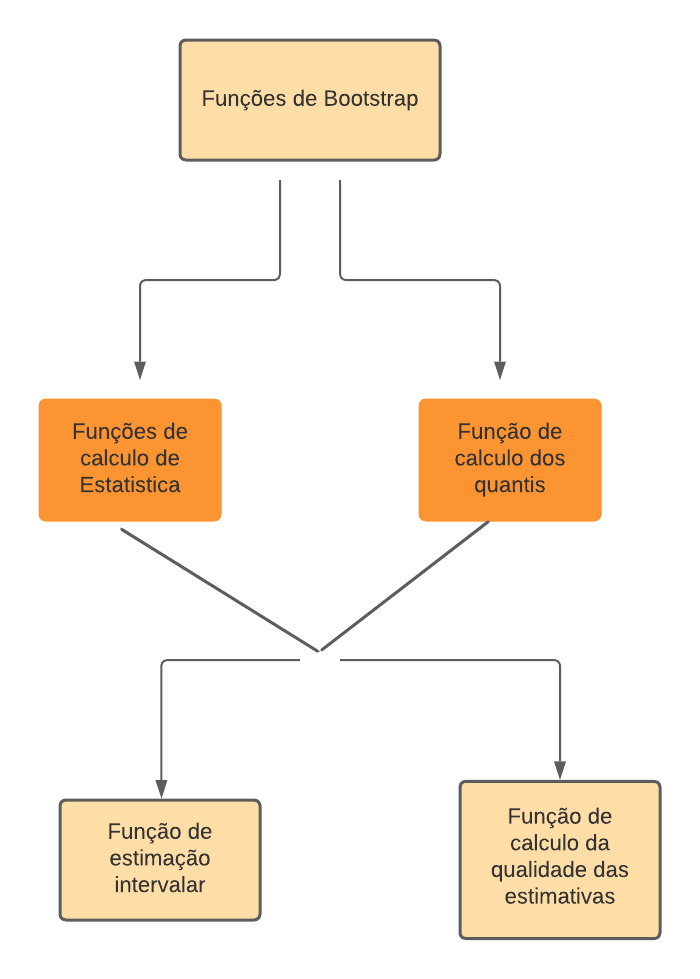